# Twitter Sentiment Classifier and Visualizations

# Counting the number of tweets received

```python
tweet_data.Polarity.value_counts()
```

```
neutral     1425
positive     771
negative     692
Name: Polarity, dtype: int64
```

## Plotting the number of tweets received

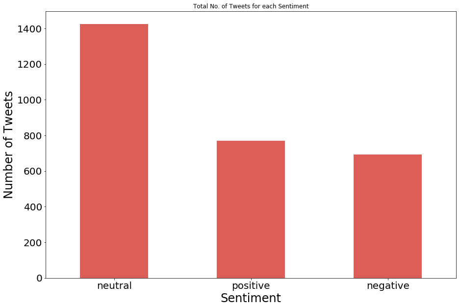

```python
colors=seaborn.color_palette("hls", 10)
pd.Series(tweet_data["Polarity"]).value_counts().plot(kind = "bar",
                        color=colors,figsize=(15,10),fontsize=20,rot = 0, title = "Total No. of Tweets for each Sentiment")
plt.xlabel('Sentiment', fontsize=24)
plt.ylabel('Number of Tweets', fontsize=24)
```

[figure not shown]

```python
colors=seaborn.color_palette("husl", 10)
pd.Series(tweet_data["Polarity"]).value_counts().plot(kind="pie",colors=colors,
    labels=["negative", "neutral", "positive"],explode=[0.05,0.02,0.04],
    shadow=True,autopct='%.2f', fontsize=12,figsize=(12,12),title = "Total Tweets for Each Sentiment")
```

### Visualization using wordcloud for the negative tweets

[figure not shown]

```python
df=tweet_data[tweet_data['Polarity']=='negative']
words = ' '.join(df['Text'])
cleaned_word = " ".join([word for word in words.split()
                            if 'http' not in word
                                and not word.startswith('@')
                                and word != 'RT'])

wordcloud = WordCloud(stopwords=STOPWORDS,
                      background_color='white',
                      width=3000,
                      height=2500
                     ).generate(cleaned_word)

plt.figure(1,figsize=(20, 20))
plt.imshow(wordcloud)
plt.axis('off')
plt.savefig('./negative_tweet_wordcloud.png', dpi=300)
plt.show()
```

### Visualization using wordcloud for the positive tweets

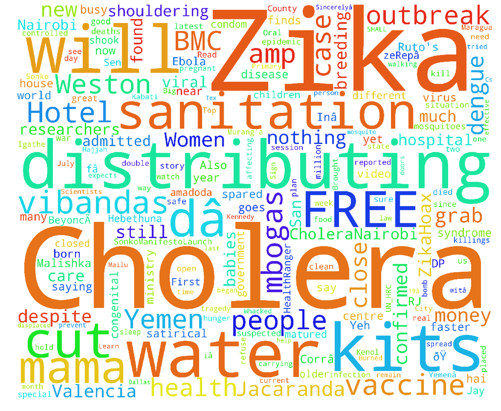

```python
df=tweet_data[tweet_data['Polarity']=='positive']
words = ' '.join(df['Text'])
cleaned_word = " ".join([word for word in words.split()
                            if 'http' not in word
                                and not word.startswith('@')
                                and word != 'RT'])

wordcloud = WordCloud(stopwords=STOPWORDS,
                      background_color='white',
                      width=3000,
                      height=2500
                     ).generate(cleaned_word)

plt.figure(1,figsize=(20, 20))
plt.imshow(wordcloud)
plt.axis('off')
plt.savefig('./positive_tweet_wordcloud.png', dpi=300)
plt.show()
```

### Visualization using wordcloud for the neutral tweets

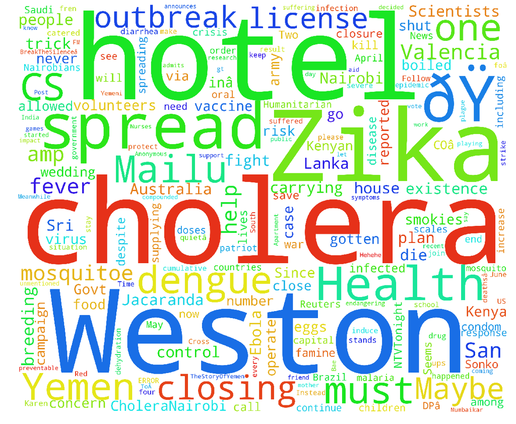

```python
df=tweet_data[tweet_data['Polarity']=='neutral']
words = ' '.join(df['Text'])
cleaned_word = " ".join([word for word in words.split()
                            if 'http' not in word
                                and not word.startswith('@')
                                and word != 'RT'])
wordcloud = WordCloud(stopwords=STOPWORDS,
                      background_color='white',
                      width=3000,
                      height=2500
                     ).generate(cleaned_word)
plt.figure(1,figsize=(20, 20))
plt.imshow(wordcloud)
plt.axis('off')
plt.savefig('./neutral_tweet_wordcloud.png', dpi=300)
plt.show()
```

# Sentiment Classifier

```python
from IPython.display import Image
from IPython.core.display import HTML
Image(url= "https://www.researchgate.net/profile/Ahmed_Rafea/publication/233859568/figure/fig1/AS:299998026715141@1448536511144/Figure-1-The-ML-process-of-the-sentence%27s-sentiment-analysis.png", width=1000, height=1000)
```

[figure not shown]

```python
def tweet_to_words(raw_tweet):
    tweet = ''.join(c for c in raw_tweet if c not in string.punctuation)
    tweet = re.sub('((www\S+)|(http\S+))', 'urlsite', tweet)
    tweet = re.sub(r'\d+', 'contnum', tweet)
    tweet = re.sub(' +',' ', tweet)
    words = tweet.lower().split()
    stops = set(stopwords.words("english"))

    meaningful_words = [w for w in words if not w in stops]
    return( " ".join( meaningful_words ))
```

```python
from sklearn.model_selection import train_test_split
tweet_data['clean_tweet']=tweet_data['Text'].apply(lambda x: tweet_to_words(x))
train,test = train_test_split(tweet_data,test_size=0.33,random_state=0)
```

```python
train_clean_tweet=[]
for tweet in train['clean_tweet']:
    train_clean_tweet.append(tweet)
test_clean_tweet=[]
for tweet in test['clean_tweet']:
    test_clean_tweet.append(tweet)
```

```python
from sklearn.feature_extraction.text import CountVectorizer
v = CountVectorizer(analyzer = "word")
train_features= v.fit_transform(train_clean_tweet)
test_features=v.transform(test_clean_tweet)
```

```python
from sklearn.linear_model import LogisticRegression
from sklearn.tree import DecisionTreeClassifier
from sklearn.ensemble import RandomForestClassifier, AdaBoostClassifier, GradientBoostingClassifier
from sklearn.naive_bayes import MultinomialNB
from sklearn.naive_bayes import BernoulliNB
from sklearn import ensemble
from sklearn import tree
from sklearn.neighbors import KNeighborsClassifier
from sklearn.metrics import accuracy_score
```

```python
Classifiers = [
    LogisticRegression(C=0.001,multi_class='multinomial',max_iter=10,solver='sag', tol=1e-1),

    RandomForestClassifier(n_estimators=200, bootstrap=True, class_weight=None, criterion='gini',
            max_depth=50, max_features='auto', max_leaf_nodes=None,
            min_samples_leaf=1, min_samples_split=2,
            min_weight_fraction_leaf=0.0, n_jobs= -1,
            oob_score=False, random_state=10),

    AdaBoostClassifier(n_estimators=100, random_state=10),

    BernoulliNB(),

    MultinomialNB(alpha=1.0, class_prior=None, fit_prior=True),

    KNeighborsClassifier(algorithm='auto', metric='minkowski',
           metric_params=None, n_neighbors=2, p=2,
           weights='uniform'),

    tree.DecisionTreeClassifier(),

    ensemble.ExtraTreesClassifier(n_estimators=100,
                                  max_features= 50,
                                  criterion= 'entropy'),

    ensemble.GradientBoostingClassifier(criterion='friedman_mse', init=None,
              learning_rate=0.001,n_estimators=50,presort='auto', random_state=None, verbose = 0)]
```

```python
from sklearn import metrics
dense_features=train_features.toarray()
dense_test= test_features.toarray()
Accuracy=[]
Model=[]
for classifier in Classifiers:
    try:
        fit = classifier.fit(train_features,train['Polarity'])
        pred = fit.predict(test_features)
    except Exception:
        fit = classifier.fit(dense_features,train['Polarity'])
        pred = fit.predict(dense_test)
    accuracy = accuracy_score(pred,test['Polarity'])
    print("***************************************************************************************************************")
    print('Accuracy of '+classifier.__class__.__name__+'is '+str(accuracy))
    print("--------------------------------------------------------------")
    Accuracy.append(accuracy)
    print("Classification report for classifier %s:\n%s\n"
      % (classifier, metrics.classification_report(test['Polarity'], pred)))
    cm = metrics.confusion_matrix(test['Polarity'], pred)
    print("--------------------------------------------------------------")
    print("Confusion matrix:\n%s" % cm)
    Model.append(classifier.__class__.__name__)
    print("***************************************************************************************************************")
```

```
Accuracy of LogisticRegressionis 0.556603773585
--------------------------------------------------------------
Classification report for classifier LogisticRegression(C=0.001, class_weight=None, dual=False, fit_intercept=True,
          intercept_scaling=1, max_iter=10, multi_class='multinomial',
          n_jobs=1, penalty='l2', random_state=None, solver='sag', tol=0.1,
          verbose=0, warm_start=False):
             precision    recall  f1-score   support

   negative       0.00      0.00      0.00       241
    neutral       0.53      1.00      0.69       477
   positive       1.00      0.23      0.37       236

avg / total       0.51      0.56      0.44       954


--------------------------------------------------------------
Confusion matrix:
[[  0 241   0]
 [  0 477   0]
 [  0 182  54]]
```

```
Accuracy of RandomForestClassifieris 0.831236897275
--------------------------------------------------------------
Classification report for classifier RandomForestClassifier(bootstrap=True, class_weight=None, criterion='gini',
            max_depth=50, max_features='auto', max_leaf_nodes=None,
            min_impurity_split=1e-07, min_samples_leaf=1,
            min_samples_split=2, min_weight_fraction_leaf=0.0,
            n_estimators=200, n_jobs=-1, oob_score=False, random_state=10,
            verbose=0, warm_start=False):
             precision    recall  f1-score   support

   negative       0.97      0.70      0.81       241
    neutral       0.75      0.99      0.86       477
   positive       0.99      0.64      0.78       236

avg / total       0.87      0.83      0.83       954


--------------------------------------------------------------
Confusion matrix:
[[169  71   1]
 [  3 474   0]
 [  2  84 150]]
Accuracy of AdaBoostClassifieris 0.827044025157
--------------------------------------------------------------
Classification report for classifier AdaBoostClassifier(algorithm='SAMME.R', base_estimator=None,
          learning_rate=1.0, n_estimators=100, random_state=10):
             precision    recall  f1-score   support

   negative       0.91      0.69      0.78       241
    neutral       0.81      0.96      0.88       477
   positive       0.80      0.69      0.74       236

avg / total       0.83      0.83      0.82       954


--------------------------------------------------------------
Confusion matrix:
[[166  45  30]
 [  6 459  12]
 [ 10  62 164]]
```

[output cut: 104 more lines]

```
              subsample=1.0, verbose=0, warm_start=False):
             precision    recall  f1-score   support

   negative       0.00      0.00      0.00       241
    neutral       0.50      1.00      0.67       477
   positive       0.00      0.00      0.00       236

avg / total       0.25      0.50      0.33       954


--------------------------------------------------------------
Confusion matrix:
[[  0 241   0]
 [  0 477   0]
 [  0 236   0]]
```

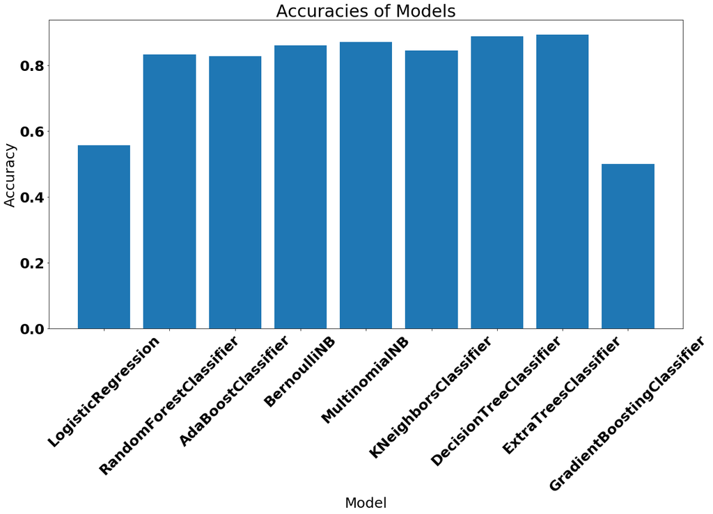

```python
Index = [1,2,3,4,5,6,7,8,9]
plt.figure(1,figsize=(20, 10))
font = {'weight' : 'bold',
        'size'   : 25}

plt.rc('font', **font)

plt.bar(Index,Accuracy)
plt.xticks(Index, Model,rotation=45)
plt.ylabel('Accuracy')
plt.xlabel('Model')
plt.title('Accuracies of Models')
```

# Word n-grams (Bag of Words - BOW)

**What it does:** A tweet (such as a sentence or a document) is represented as the bag (multiset) of its words, disregarding grammar and even word order but keeping multiplicity.

```python
from IPython.display import Image
from IPython.core.display import HTML
Image(url= "https://sensblogs.files.wordpress.com/2011/08/bow1.jpg", width=1000, height=1000)
```

[figure not shown]

```python
from collections import OrderedDict, defaultdict, Counter
import pandas as pd
import csv
from nltk.tokenize import TweetTokenizer
from sklearn.feature_extraction.text import CountVectorizer
```

```python
tweets = tweet_data['Text']
cv = CountVectorizer(ngram_range=(1,2), min_df=3, max_df=.95, stop_words='english')
bow = cv.fit_transform(tweets)

# use below if you need a data frame
bow_df = pd.DataFrame(bow.toarray(), index=tweets.index, columns=cv.get_feature_names())
```

# Feature Evaluation

```python
from sklearn.naive_bayes import BernoulliNB, MultinomialNB
from sklearn.svm import SVC
from sklearn.ensemble import RandomForestClassifier
from sklearn.linear_model import LogisticRegressionCV
from sklearn.preprocessing import Binarizer, StandardScaler
from sklearn.ensemble import VotingClassifier
from sklearn.cross_validation import cross_val_score
```

```python
X, Y = bow, (tweet_data['Polarity']).ravel()

binarize = Binarizer()
X = binarize.fit_transform(X)

X_train, X_test, y_train, y_test = \
    train_test_split(X, Y,test_size=0.3)

model = MultinomialNB()
model.fit(X_train, y_train)

preds = model.predict(X_test)

accuracy = accuracy_score(preds, y_test)
print("***************************************************************************************************************")
print('Accuracy is ' + str(accuracy))
print("--------------------------------------------------------------")
print("Classification report for classifier %s:\n%s\n"
      % (classifier, metrics.classification_report(y_test, preds)))
cm = metrics.confusion_matrix(y_test, preds)
print("--------------------------------------------------------------")
print("Confusion matrix:\n%s" % cm)
```

```
Accuracy is 0.844290657439
--------------------------------------------------------------
Classification report for classifier GradientBoostingClassifier(criterion='friedman_mse', init=None,
              learning_rate=0.001, loss='deviance', max_depth=3,
              max_features=None, max_leaf_nodes=None,
              min_impurity_split=1e-07, min_samples_leaf=1,
              min_samples_split=2, min_weight_fraction_leaf=0.0,
              n_estimators=50, presort='auto', random_state=None,
              subsample=1.0, verbose=0, warm_start=False):
             precision    recall  f1-score   support

   negative       0.76      0.87      0.81       201
    neutral       0.88      0.87      0.87       428
   positive       0.86      0.77      0.82       238

avg / total       0.85      0.84      0.84       867


--------------------------------------------------------------
Confusion matrix:
[[175  20   6]
 [ 32 373  23]
 [ 22  32 184]]
```

```python
X, Y = bow, (tweet_data['Polarity']).ravel()
ss = StandardScaler()
X = X.toarray()
X = ss.fit_transform(X)

X_train, X_test, y_train, y_test = \
    train_test_split(X, Y,test_size=0.3)

model = SVC()
model.fit(X_train, y_train)

preds = model.predict(X_test)

accuracy = accuracy_score(preds, y_test)
print("***************************************************************************************************************")
print('Accuracy is '+str(accuracy))
print("--------------------------------------------------------------")
print("Classification report for classifier %s:\n%s\n"
      % (classifier, metrics.classification_report(y_test, preds)))
cm = metrics.confusion_matrix(y_test, preds)
print("--------------------------------------------------------------")
print("Confusion matrix:\n%s" % cm)
```

```
Accuracy is 0.83506343714
--------------------------------------------------------------
Classification report for classifier GradientBoostingClassifier(criterion='friedman_mse', init=None,
              learning_rate=0.001, loss='deviance', max_depth=3,
              max_features=None, max_leaf_nodes=None,
              min_impurity_split=1e-07, min_samples_leaf=1,
              min_samples_split=2, min_weight_fraction_leaf=0.0,
              n_estimators=50, presort='auto', random_state=None,
              subsample=1.0, verbose=0, warm_start=False):
             precision    recall  f1-score   support

   negative       0.99      0.68      0.81       213
    neutral       0.75      1.00      0.85       423
   positive       0.99      0.68      0.81       231

avg / total       0.87      0.84      0.83       867


--------------------------------------------------------------
Confusion matrix:
[[145  68   0]
 [  1 421   1]
 [  0  73 158]]
```

```python
models = [('mNB' , MultinomialNB()),
          ('bNB' , BernoulliNB()),
          ('svc' , SVC())]
```

```python
print('{0}\t{1:<1}\t{2:<4}\t{3:<4}'.format("ACCURACY", "MEAN", "MIN", "MAX"))

for name, model in models:
    X, Y = bow, (tweet_data['Polarity']).ravel()

    if name == 'bNB':
        binarize = Binarizer()
        X = binarize.fit_transform(X)
    elif name == 'svc':
        ss = StandardScaler()
        X = X.toarray()
        X = ss.fit_transform(X)

    cv = cross_val_score(model, X, Y, cv=5, scoring='accuracy')

    print('{0}\t{1:<3}\t{2:<4}\t{3:<4}'.format(name, round(cv.mean(), 4), round(cv.min(), 4), round(cv.max(), 4)))
```

```
ACCURACY	MEAN	MIN 	MAX
mNB	0.7811	0.6153	0.8336
bNB	0.7842	0.6516	0.827
```

```
svc	0.8009	0.7106	0.844
```

# TF-IDF Vectorizer

## Data Processing

```python
def split_into_tokens(Text):
    return TextBlob(Text).words
```

##### Here are some of the original texts again:

```python
tweet_data.Text.head()
```

```
0    RT @GrantBrooke: On Cholera: @TwigaFoods will ...
1     Good! Now SAVE THE BEES! https://t.co/x7qMctrlSg
2    Jubilee gvt shuts Jacaranda &amp; San Valencia...
3    So what?... Does it make less of cholera https...
4    RT @washingtonpost: Scientists plan to trick Z...
Name: Text, dtype: object
```

```python
tweet_data.Text.apply(split_into_tokens)
```

```
0       [RT, GrantBrooke, On, Cholera, TwigaFoods, wil...
1       [Good, Now, SAVE, THE, BEES, https, t.co/x7qMc...
2       [Jubilee, gvt, shuts, Jacaranda, amp, San, Val...
3       [So, what, Does, it, make, less, of, cholera, ...
4       [RT, washingtonpost, Scientists, plan, to, tri...
5       [This, is, a, 90s, Dimension, Films, premise, ...
6       [dayanandnene, It, is, stupid, on, part, of, S...
7       [RT, Mwirigi, Jacaranda, Hotel, and, San, Vale...
8       [RT, washingtonpost, Scientists, plan, to, tri...
9       [RT, PeachSkwebu, Also, still, shook, at, Jay,...
10      [This, is, literally, what, they, are, doing, ...
11      [RT, ashok_rais, CholeraNairobi, Mike, Sonko, ...
12      [RT, waglenikhil, This, is, blackmailing, Mumb...
13      [RT, washingtonpost, Scientists, plan, to, tri...
14      [RT, washingtonpost, Scientists, plan, to, tri...
```

[output cut: 47 more lines]

```python
def split_into_lemmas(Text):
    Text = Text.lower()
    words = TextBlob(Text).words
    # for each word, take its "base form" = lemma
    return [word.lemma for word in words]
```

```python
bow_transformer = CountVectorizer(analyzer=split_into_lemmas).fit(tweet_data['Text'])
print(len(bow_transformer.vocabulary_))
```

```
5662
```

```python
tweet1 = tweet_data['Text'][0]
print(tweet1)
```

```
RT @GrantBrooke: On Cholera: @TwigaFoods will be distributing to 2,000 mama mbogas and vibandas FREE water sanitation kits. Let's cut the dâ€¦
```

```python
bow1 = bow_transformer.transform([tweet1])
print(bow1)
print(bow1.shape)
```

```
  (0, 14)	1
  (0, 80)	1
  (0, 337)	1
  (0, 523)	1
  (0, 803)	1
  (0, 1033)	1
  (0, 1205)	1
  (0, 1279)	1
  (0, 1600)	1
  (0, 1734)	1
  (0, 2286)	1
  (0, 2373)	1
  (0, 2502)	1
  (0, 2547)	1
  (0, 2902)	1
  (0, 3422)	1
  (0, 3472)	1
  (0, 5025)	1
  (0, 5089)	1
  (0, 5174)	1
  (0, 5303)	1
  (0, 5383)	1
  (0, 5456)	1
(1, 5662)
```

### sparse matrix:

```python
tweets_bow = bow_transformer.transform(tweet_data['Text'])
print('sparse matrix shape:', tweets_bow.shape)
print('number of non-zeros:', tweets_bow.nnz)
print('sparsity: %.2f%%' % (100.0 * tweets_bow.nnz / (tweets_bow.shape[0] * tweets_bow.shape[1])))
```

```
sparse matrix shape: (2888, 5662)
number of non-zeros: 51498
sparsity: 0.31%
```

### And finally, after the counting, the term weighting and normalization can be done with TF-IDF, using scikit-learn's TfidfTransformer:

```python
tfidf_transformer = TfidfTransformer().fit(tweets_bow)
tfidf1 = tfidf_transformer.transform(bow1)
print(tfidf1)
```

```
  (0, 5456)	0.225572672196
  (0, 5383)	0.212425163215
  (0, 5303)	0.239886931855
  (0, 5174)	0.241567962896
  (0, 5089)	0.110292765937
  (0, 5025)	0.127436721973
  (0, 3472)	0.237450397794
  (0, 3422)	0.0863281704507
  (0, 2902)	0.191017764023
  (0, 2547)	0.241567962896
  (0, 2502)	0.241567962896
  (0, 2373)	0.231759118445
  (0, 2286)	0.237849687908
  (0, 1734)	0.222702967971
  (0, 1600)	0.240302801618
  (0, 1279)	0.239063728008
  (0, 1205)	0.229625417108
  (0, 1033)	0.241143276033
  (0, 803)	0.0945228365968
  (0, 523)	0.18557497716
  (0, 337)	0.154743826976
  (0, 80)	0.241567962896
  (0, 14)	0.176986818131
```

### To transform the entire bag-of-words corpus into TF-IDF corpus at once:

```python
tweets_tfidf = tfidf_transformer.transform(tweets_bow)
print(tweets_tfidf.shape)
```

```
(2888, 5662)
```

There are a multitude of ways in which data can be proprocessed and vectorized. These two steps, also called "feature engineering", are typically the most time consuming and "unsexy" parts of building a predictive pipeline, but they are very important and require some experience. The trick is to evaluate constantly: analyze model for the errors it makes, improve data cleaning & preprocessing, brainstorm for new features, evaluate...

## Training a model based on TF-IDF

# Naive Bayes

```python
%time polarity_detector = MultinomialNB().fit(tweets_tfidf, tweet_data['Polarity'])
```

```
Wall time: 25 ms
```

### Let's try classifying our single random tweet:

```python
print('predicted:', polarity_detector.predict(tfidf1[0]))
print('expected:', tweet_data.Polarity[0])
```

```
predicted: ['positive']
expected: positive
```

```python
all_predictions = polarity_detector.predict(tweets_tfidf)
print(all_predictions)
```

```
['positive' 'positive' 'positive' ..., 'negative' 'negative' 'negative']
```

```python
print('accuracy', accuracy_score(tweet_data['Polarity'], all_predictions))
print('confusion matrix\n', confusion_matrix(tweet_data['Polarity'], all_predictions))
print('(row=expected, col=predicted)')
```

```
accuracy 0.94148199446
confusion matrix
 [[ 620   68    4]
 [   3 1420    2]
 [  11   81  679]]
(row=expected, col=predicted)
```

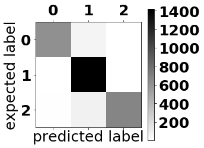

```python
plt.figure(figsize=(10,10))
plt.matshow(confusion_matrix(tweet_data['Polarity'], all_predictions), cmap=plt.cm.binary, interpolation='nearest')
plt.colorbar()
plt.ylabel('expected label')
plt.xlabel('predicted label')
```

```python
print(classification_report(tweet_data['Polarity'], all_predictions))
```

```
             precision    recall  f1-score   support

   negative       0.98      0.90      0.94       692
    neutral       0.91      1.00      0.95      1425
   positive       0.99      0.88      0.93       771

avg / total       0.95      0.94      0.94      2888
```

# SVC

```python
%time polarity_detector = SVC().fit(tweets_tfidf, tweet_data['Polarity'])
```

```
Wall time: 2.73 s
```

```python
print('predicted:', polarity_detector.predict(tfidf1[0]))
print('expected:', tweet_data.Polarity[0])
```

```
predicted: ['neutral']
expected: positive
```

```python
all_predictions = polarity_detector.predict(tweets_tfidf)
print(all_predictions)
```

```
['neutral' 'neutral' 'neutral' ..., 'neutral' 'neutral' 'neutral']
```

```python
print('accuracy', accuracy_score(tweet_data['Polarity'], all_predictions))
print('confusion matrix\n', confusion_matrix(tweet_data['Polarity'], all_predictions))
print('(row=expected, col=predicted)')
```

```
accuracy 0.493421052632
confusion matrix
 [[   0  692    0]
 [   0 1425    0]
 [   0  771    0]]
(row=expected, col=predicted)
```

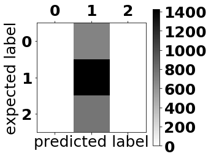

```python
plt.matshow(confusion_matrix(tweet_data['Polarity'], all_predictions), cmap=plt.cm.binary, interpolation='nearest')
plt.colorbar()
plt.ylabel('expected label')
plt.xlabel('predicted label')
```

### Another Approach- training and testing

```python
X_train, X_test, y_train, y_test = \
    train_test_split(tweet_data['Text'], tweet_data['Polarity'], test_size=0.2)
```

```python
from sklearn.feature_extraction.text import TfidfVectorizer
vectorizer = TfidfVectorizer(min_df=5, max_df = 0.8, sublinear_tf=True, use_idf=True,stop_words='english')
train_corpus_tf_idf = vectorizer.fit_transform(X_train)
test_corpus_tf_idf = vectorizer.transform(X_test)
```

```python
svm_model = LinearSVC()
nb_model = MultinomialNB()
```

```python
svm_model.fit(train_corpus_tf_idf,y_train)
nb_model.fit(train_corpus_tf_idf,y_train)
```

```
MultinomialNB(alpha=1.0, class_prior=None, fit_prior=True)
```

```python
svm_result = svm_model.predict(test_corpus_tf_idf)
nb_result = nb_model.predict(test_corpus_tf_idf)
```

## Get the accuracy of the model- SVM(TFIDF)

```
accuracy 0.878892733564
confusion matrix
 [[117  22   5]
 [  6 281  15]
 [  7  15 110]]
(row=expected, col=predicted)
```

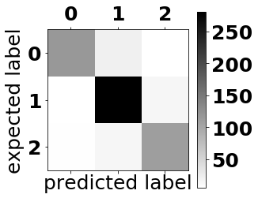

```python
print('accuracy', accuracy_score(y_test, svm_result))
print('confusion matrix\n', confusion_matrix(y_test, svm_result))
print('(row=expected, col=predicted)')
plt.matshow(confusion_matrix(y_test, svm_result), cmap=plt.cm.binary, interpolation='nearest')
plt.colorbar()
plt.ylabel('expected label')
plt.xlabel('predicted label')
```

## Get the accuracy of the model- NB(TFIDF)

```
accuracy 0.832179930796
confusion matrix
 [[110  29   5]
 [  7 279  16]
 [ 11  29  92]]
(row=expected, col=predicted)
```

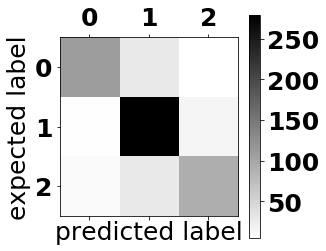

```python
print('accuracy', accuracy_score(y_test, nb_result))
print('confusion matrix\n', confusion_matrix(y_test, nb_result))
print('(row=expected, col=predicted)')
plt.matshow(confusion_matrix(y_test, nb_result), cmap=plt.cm.binary, interpolation='nearest')
plt.colorbar()
plt.ylabel('expected label')
plt.xlabel('predicted label')
```

## Now, we will include the n-gram analysis to our model, lets see how does it affect

### Bigrams are pairs of consecutive words. In general N-grams are tuples of N consecutive words.

## Uni-gram and Bi-gram Analysis

### By using bigrams, we preserve “more context” for the words in the text.

We’re going to build:

- **Unigram classifier (with mark_negation and without)**
- **Bigram classifier (with mark_negation and without)**
- **Unigram and bigram classifier (with mark_negation and without)**

## Unigram Classifier

```python
from nltk import word_tokenize
from nltk.sentiment.util import mark_negation
from sklearn.feature_extraction.text import CountVectorizer
from sklearn.pipeline import Pipeline
from sklearn.svm import LinearSVC
from sklearn.base import TransformerMixin


clf = Pipeline([
    ('vectorizer', CountVectorizer(analyzer="word",
                                   tokenizer=word_tokenize,         # ! Comment line to include mark_negation and uncomment next line
                                   #tokenizer=lambda text: mark_negation(word_tokenize(text)),
                                   preprocessor=lambda text: text.replace("<br />", " "),
                                   max_features=10000) ),
    ('classifier', LinearSVC())
])

clf.fit(X_train, y_train)
clf.score(X_test, y_test)
```

```
0.88754325259515576
```

```python
from nltk import word_tokenize
from nltk.sentiment.util import mark_negation
from sklearn.feature_extraction.text import CountVectorizer
from sklearn.pipeline import Pipeline
from sklearn.svm import LinearSVC
from sklearn.base import TransformerMixin

clf = Pipeline([
    ('vectorizer', CountVectorizer(analyzer="word",
                                   #tokenizer=word_tokenize,         # ! Comment line to include mark_negation and uncomment next line
                                   tokenizer=lambda text: mark_negation(word_tokenize(text)),
                                   preprocessor=lambda text: text.replace("<br />", " "),
                                   max_features=10000) ),
    ('classifier', LinearSVC())
])

clf.fit(X_train, y_train)
clf.score(X_test, y_test)
```

```
0.89446366782006925
```

## Bigram Classfier

```python
bigram_clf = Pipeline([
    ('vectorizer', CountVectorizer(analyzer="word",
                                   ngram_range=(2, 2),
                                   tokenizer=word_tokenize,
                                   # tokenizer=lambda text: mark_negation(word_tokenize(text)),
                                   preprocessor=lambda text: text.replace("<br />", " "),)),
    ('classifier', LinearSVC())
])

bigram_clf.fit(X_train, y_train)
bigram_clf.score(X_test, y_test)
```

```
0.88581314878892736
```

```python
bigram_clf = Pipeline([
    ('vectorizer', CountVectorizer(analyzer="word",
                                   ngram_range=(2, 2),
                                   # tokenizer=word_tokenize,
                                   tokenizer=lambda text: mark_negation(word_tokenize(text)),
                                   preprocessor=lambda text: text.replace("<br />", " "),)),
    ('classifier', LinearSVC())
])

bigram_clf.fit(X_train, y_train)
bigram_clf.score(X_test, y_test)
```

```
0.88581314878892736
```

## Unigram and Bigram classifier

- Just by changing the ngram_range to (1, 2) we obtain the unigram and bigram model

```python
unigram_bigram_clf = Pipeline([
    ('vectorizer', CountVectorizer(analyzer="word",
                                   ngram_range=(1, 2),
                                   tokenizer=word_tokenize,
                                   # tokenizer=lambda text: mark_negation(word_tokenize(text)),
                                   preprocessor=lambda text: text.replace("<br />", " "),)),
    ('classifier', LinearSVC())
])

unigram_bigram_clf.fit(X_train, y_train)
unigram_bigram_clf.score(X_test, y_test)
```

```
0.89100346020761245
```

```python
unigram_bigram_clf = Pipeline([
    ('vectorizer', CountVectorizer(analyzer="word",
                                   ngram_range=(1, 2),
                                   #tokenizer=word_tokenize,
                                   tokenizer=lambda text: mark_negation(word_tokenize(text)),
                                   preprocessor=lambda text: text.replace("<br />", " "),)),
    ('classifier', LinearSVC())
])

unigram_bigram_clf.fit(X_train, y_train)
unigram_bigram_clf.score(X_test, y_test)
```

```
0.88754325259515576
```

# LSTM Networks

### Long Short Term Memory networks – usually just called “LSTMs” – are a special kind of RNN, capable of learning long-term dependencies.

```python
from IPython.display import Image
from IPython.core.display import HTML
Image(url= "https://deeplearning4j.org/img/greff_lstm_diagram.png", width=1000, height=1000)
```

[figure not shown]

```python
def preprocess_data(data):

    mod_post = []
    mod_polarity = []

    for index, row in data.iterrows():
        post = row['Text']
        cleaned_post = ' '.join(re.sub("(@[A-Za-z0-9]+)|([^0-9A-Za-z \t])|(\w+:\/\/\S+)"," ", str(post)).split())
        mod_post.append(cleaned_post)

        polarity = row['Polarity']
        if polarity == 'negative': # negative
            mod_polarity.append(-1)
        elif polarity == 'neutral':
            mod_polarity.append(0)
        else:
            mod_polarity.append(1)

    data['mod_post'] = mod_post
    data['mod_polarity'] = mod_polarity
```

```python
preprocess_data(tweet_data)
```

```python
tweet_data.Polarity.value_counts()
```

```
neutral     1425
positive     771
negative     692
Name: Polarity, dtype: int64
```

```python
tweet_data.head()
```

|  | Polarity | Text | length | clean_tweet | mod_post | mod_polarity |
| --- | --- | --- | --- | --- | --- | --- |
| 0 | positive | RT @GrantBrooke: On Cholera: @TwigaFoods will ... | 142 | rt grantbrooke cholera twigafoods distributing... | RT On Cholera will be distributing to 2 000 ma... | 1 |
| 1 | positive | Good! Now SAVE THE BEES! https://t.co/x7qMctrlSg | 48 | good save bees urlsite | Good Now SAVE THE BEES | 1 |
| 2 | positive | Jubilee gvt shuts Jacaranda &amp; San Valencia... | 142 | jubilee gvt shuts jacaranda amp san valencia h... | Jubilee gvt shuts Jacaranda amp San Valencia h... | 1 |
| 3 | negative | So what?... Does it make less of cholera https... | 64 | make less cholera urlsite | So what Does it make less of cholera | -1 |
| 4 | neutral | RT @washingtonpost: Scientists plan to trick Z... | 135 | rt washingtonpost scientists plan trick zikaca... | RT Scientists plan to trick Zika carrying mosq... | 0 |

```python
modified_train_data = tweet_data.drop(['Text', 'Polarity', 'clean_tweet', 'length'], axis=1)
```

```python
modified_train_data.mod_polarity.value_counts()
```

```
 0    1425
 1     771
-1     692
Name: mod_polarity, dtype: int64
```

```python
modified_train_data.head()
```

|  | mod_post | mod_polarity |
| --- | --- | --- |
| 0 | RT On Cholera will be distributing to 2 000 ma... | 1 |
| 1 | Good Now SAVE THE BEES | 1 |
| 2 | Jubilee gvt shuts Jacaranda amp San Valencia h... | 1 |
| 3 | So what Does it make less of cholera | -1 |
| 4 | RT Scientists plan to trick Zika carrying mosq... | 0 |

# Keras RNN (LSTM)

```python
from keras.models import Sequential
from keras.layers import Dense, Activation, Embedding, LSTM
from keras.preprocessing import sequence
from keras.preprocessing.text import Tokenizer
from keras.preprocessing.sequence import pad_sequences
from keras.optimizers import Adam
from keras.callbacks import EarlyStopping, Callback
from keras.layers import Dropout
```

#### As a pre-processing step, we convert the sentence into word tokens. The word tokens are then mapped to a (numerical) word index. The final step involves 'padding' the list of indices with zeros to ensure every row has the same length.

#### Splitting the data into training and testing

```python
import numpy as np
from sklearn.cross_validation import train_test_split
X_train, X_test, y_train, y_test = train_test_split(np.array(modified_train_data.mod_post),
                                                    np.array(modified_train_data.mod_polarity), random_state=1 ,test_size=0.4)
```

```python
token = Tokenizer(num_words=2000, lower=True, split=" ")
token.fit_on_texts(X_train)
token.fit_on_texts(X_test)

X_train_sequence = token.texts_to_sequences(X_train)
X_test_sequence = token.texts_to_sequences(X_test)
```

```python
# truncate and pad input sequences
max_review_length = 500
```

```python
# pad the setences
X_train_pad_sequence = sequence.pad_sequences(X_train_sequence, maxlen=max_review_length)
X_test_pad_sequence = sequence.pad_sequences(X_test_sequence, maxlen=max_review_length)
```

```python
X_train_pad_sequence.shape
```

```
(1732, 500)
```

```python
X_test_pad_sequence.shape
```

```
(1156, 500)
```

```python
top_words = 5000
```

```python
# hyperparameter tuning
optimizer = Adam(lr = 0.001)
objective = "binary_crossentropy"
embedding_vecor_length = 32
```

### building the RNN LSTM model

```python
# create the model
model = Sequential()

model.add(Embedding(top_words, embedding_vecor_length, input_length=max_review_length))
model.add(Dropout(0.2))

model.add(LSTM(100))
model.add(Dropout(0.2))

model.add(Dense(1, activation="sigmoid"))

model.compile(loss=objective, optimizer=optimizer, metrics=["accuracy"])
```

```python
print(model.summary())
```

```
_________________________________________________________________
Layer (type)                 Output Shape              Param #
=================================================================
embedding_1 (Embedding)      (None, 500, 32)           160000
_________________________________________________________________
dropout_1 (Dropout)          (None, 500, 32)           0
_________________________________________________________________
lstm_1 (LSTM)                (None, 100)               53200
_________________________________________________________________
dropout_2 (Dropout)          (None, 100)               0
_________________________________________________________________
dense_1 (Dense)              (None, 1)                 101
=================================================================
Total params: 213,301.0
Trainable params: 213,301.0
Non-trainable params: 0.0
_________________________________________________________________
None
```

```python
# callback for loss logging per epoch
class LossHistory(Callback):
    def on_train_begin(self, logs={}):
        self.losses = []
        self.val_losses = []

    def on_epoch_end(self, batch, logs={}):
        self.losses.append(logs.get('loss'))
        self.val_losses.append(logs.get('val_loss'))
```

## Training the LSTM model

```python
history = LossHistory()

early_stopping = EarlyStopping(monitor='val_loss', patience=4, verbose=1, mode='auto')

model.fit(X_train_pad_sequence,
          y_train,
          batch_size=10,
          epochs=9,
          validation_data=(X_test_pad_sequence, y_test),
          verbose=1,
          shuffle=True,
          callbacks=[history, early_stopping])
```

```
Train on 1732 samples, validate on 1156 samples
```

```
<keras.callbacks.History at 0x2102682afd0>
```